# Project_1

Author

Milo Coolman

All work presented is my own, and I have followed all rules for collaboration. I have not discussed this project with anyone outside of students currently enrolled in this course, and I have listed any such students at the top of my project. If I used any AI, StackExchange, etc. on this assignment, I have clearly stated both (1) what my search prompt was and (2) what I used from the AI answer. - Milo Coolman

# Question 1

```r
slumajors_cs_stat_math <- slumajors_df |> filter(major == "Mathematics" |
                                                   major == "Computer Science" |
                                                   major == "Statistics") |>
  filter(year >= 2000)
slumajors_cs_stat_math
```

```
# A tibble: 69 × 4
   major             year n_majors n_graduates
   <chr>            <dbl>    <dbl>       <dbl>
 1 Computer Science  2000        2         425
 2 Computer Science  2001        2         400
 3 Computer Science  2002        2         408
 4 Computer Science  2003        3         452
 5 Computer Science  2004        3         510
 6 Computer Science  2005        3         434
 7 Computer Science  2006        9         510
 8 Computer Science  2007       10         500
 9 Computer Science  2008        4         500
10 Computer Science  2009        8         444
# ℹ 59 more rows
```

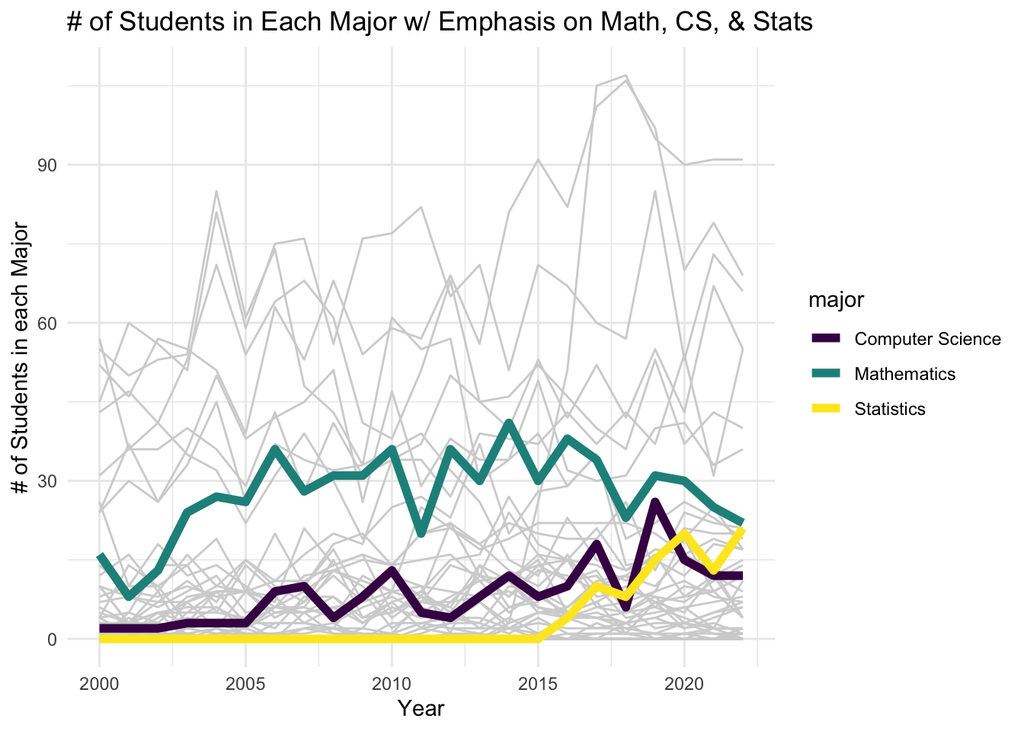

```r
ggplot(data = slumajors_df |> filter(year >= 2000), aes(x = year, y = n_majors, group = major)) +
  geom_line(show.legend = FALSE, colour = "lightgray") +
  geom_line(data = slumajors_cs_stat_math, aes(colour = major), linewidth = 2) +
  theme_minimal() +
  scale_color_viridis_d() +
  labs(title = "# of Students in Each Major w/ Emphasis on Math, CS, & Stats",
       x = "Year",
       y = "# of Students in each Major")
```

# Question 2-3

```r
slumajors_mcss <- slumajors_df |> filter(major == "Mathematics" |
           major == "Statistics" |
           major == "Computer Science" |
           major == "Economics/Math (BA)" |
           major == "Economics/Math (BS)") |>
  group_by(year) |>
  mutate(n_total_mccs = sum(n_majors))
slumajors_mcss
```

```
# A tibble: 365 × 5
# Groups:   year [73]
   major             year n_majors n_graduates n_total_mccs
   <chr>            <dbl>    <dbl>       <dbl>        <dbl>
 1 Computer Science  1950        0         296           18
 2 Computer Science  1951        0         304           19
 3 Computer Science  1952        0         315           13
 4 Computer Science  1953        0         258           14
 5 Computer Science  1954        0         317           13
 6 Computer Science  1955        0         239           16
 7 Computer Science  1956        0         247           21
 8 Computer Science  1957        0         269           29
 9 Computer Science  1958        0         272           17
10 Computer Science  1959        0         288           19
# ℹ 355 more rows
```

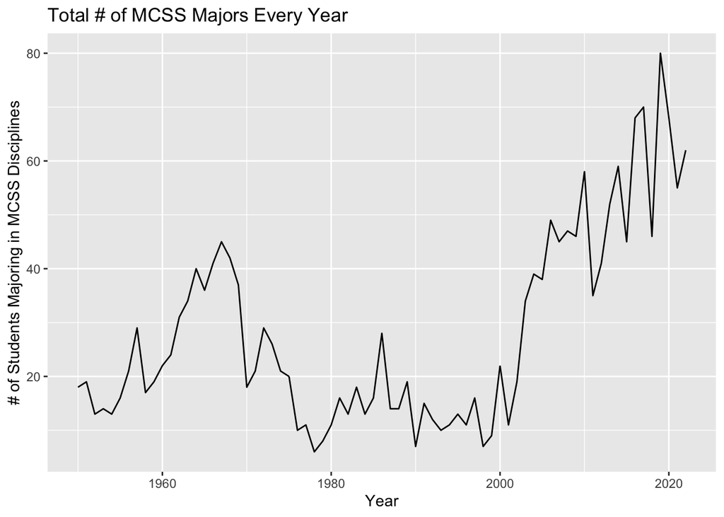

```r
ggplot(data = slumajors_mcss, aes(x = year, y = n_total_mccs)) +
  geom_line() +
  labs(title = "Total # of MCSS Majors Every Year",
       x = "Year",
       y = "# of Students Majoring in MCSS Disciplines")
```

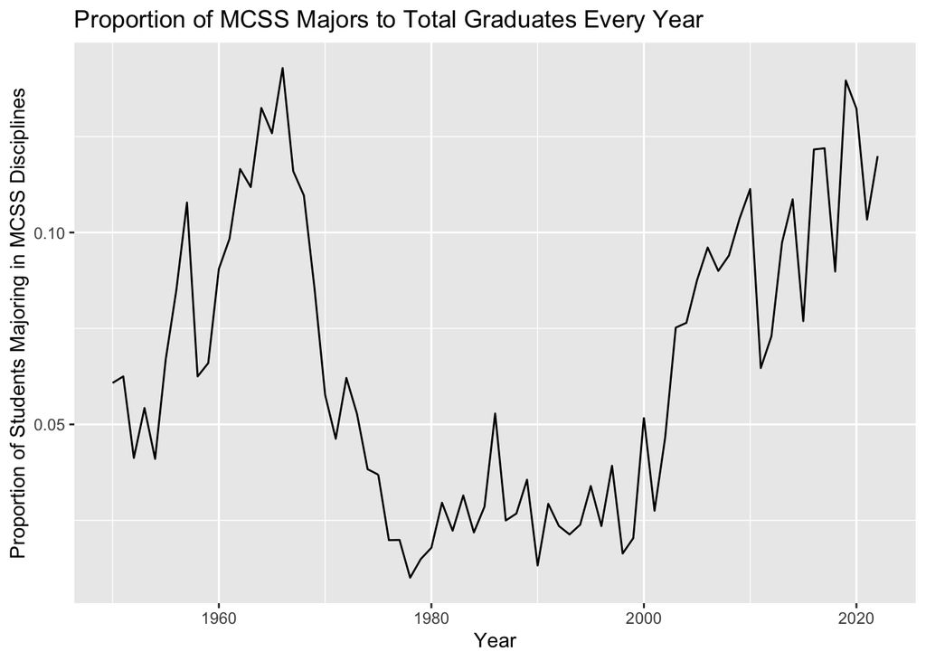

```r
ggplot(data = slumajors_mcss, aes(x = year, y = (n_total_mccs / n_graduates))) +
  geom_line() +
  labs(title = "Proportion of MCSS Majors to Total Graduates Every Year",
       x = "Year",
       y = "Proportion of Students Majoring in MCSS Disciplines")
```

# Question 4

# Question 5

```r
slumajors_50s <- slumajors_df |> filter(year <= 1959) |>
  group_by(major) |>
  summarise(n_total = sum(n_majors)) |>
  arrange(desc(n_total)) |> slice(1:5)
slumajors_50s
```

```
# A tibble: 5 × 2
  major                    n_total
  <chr>                      <dbl>
1 Business Administration*     516
2 Psychology                   372
3 Sociology                    372
4 English                      313
5 Mathematics                  179
```

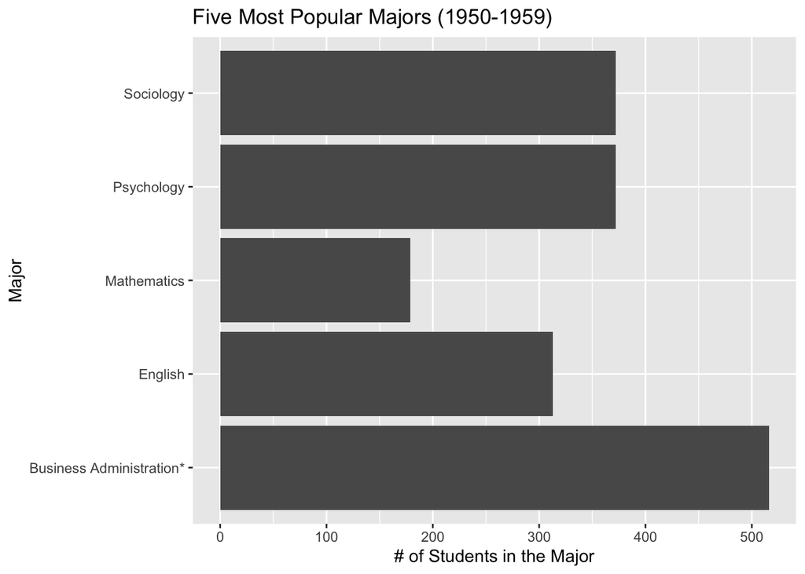

```r
ggplot(data = slumajors_50s, aes(x = n_total, y = major)) +
  geom_col() +
  labs(title = "Five Most Popular Majors (1950-1959)",
       x = "# of Students in the Major",
       y = "Major")
```

```r
slumajors_last10 <- slumajors_df |> filter(year >= 2013) |>
  group_by(major) |>
  summarise(n_total = sum(n_majors)) |>
  arrange(desc(n_total)) |> slice(1:5)
slumajors_last10
```

```
# A tibble: 5 × 2
  major                        n_total
  <chr>                          <dbl>
1 Economics                        832
2 Business in the Liberal Arts     659
3 Psychology                       654
4 Government                       494
5 Biology                          438
```

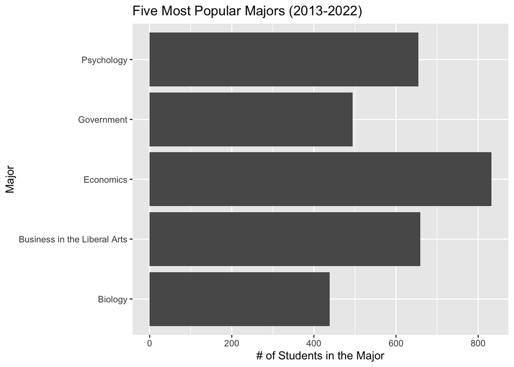

```r
ggplot(data = slumajors_last10, aes(x = n_total, y = major)) +
  geom_col() +
  labs(title = "Five Most Popular Majors (2013-2022)",
       x = "# of Students in the Major",
       y = "Major")
```

# Question 6

In the 1950s, the 5 most popular majors at SLU from most popular to least, were Business Administration, Psychology & Sociolocy, English, and Mathematics. In the last 10 years, (2013-2022) the 5 most popular majors from most popular to least were Economics, Business in the Liberal Arts, Psychology, Government, and Biology.

# Question 7

What caused the fall of stem majors right before 1980, and what caused the number of stem majors to climb again in recent years?

# Question 8

Question: Among students who are double or triple majors, what are the 3 most popular majors for both male and female students?

Answer: The three most popular majors among male double/triple majors are Business, Economics, and Government. The same thing for female majors showed that the most popular were Business, Psychology and Economics.

```r
majors_option2 <- majors_option1 |> pivot_wider(names_from = "major_num", values_from = "major") |> filter(is.na(major2) != TRUE)

majors_option2m <- majors_option2 |> filter(sex == "M")
majors_option2f <- majors_option2 |> filter(sex == "F")

majors_option2m <- majors_option2m |> pivot_longer(c(major1, major2, major3),
                                names_to = "major_num",
                                values_to = "major") |>
  filter(is.na(major) != TRUE)
majors_option2f <- majors_option2f |> pivot_longer(c(major1, major2, major3),
                                names_to = "major_num",
                                values_to = "major") |>
  filter(is.na(major) != TRUE)

majors_option2m <- majors_option2m |> group_by(major) |>
  summarise(n_total = n())
majors_option2m <- majors_option2m |> arrange(desc(n_total)) |>
  slice(1:3)
majors_option2m
```

```
# A tibble: 3 × 2
  major n_total
  <chr>   <int>
1 BUSLA     410
2 ECON      330
3 GOVT       86
```

```r
majors_option2f <- majors_option2f|> group_by(major) |>
  summarise(n_total = n())
majors_option2f <- majors_option2f |> arrange(desc(n_total)) |>
  slice(1:3)
majors_option2f
```

```
# A tibble: 3 × 2
  major n_total
  <chr>   <int>
1 BUSLA     271
2 PSYC      173
3 ECON      122
```

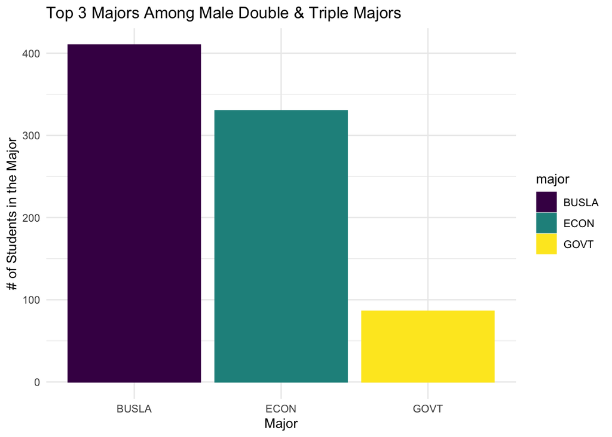

```r
ggplot(data = majors_option2m, aes(x = major, y = n_total)) +
  geom_col(aes(colour = major, fill = major)) +
  labs(title = "Top 3 Majors Among Male Double & Triple Majors",
       x = "Major",
       y = "# of Students in the Major") +
  scale_colour_viridis_d() +
  scale_fill_viridis_d() +
  theme_minimal()
```

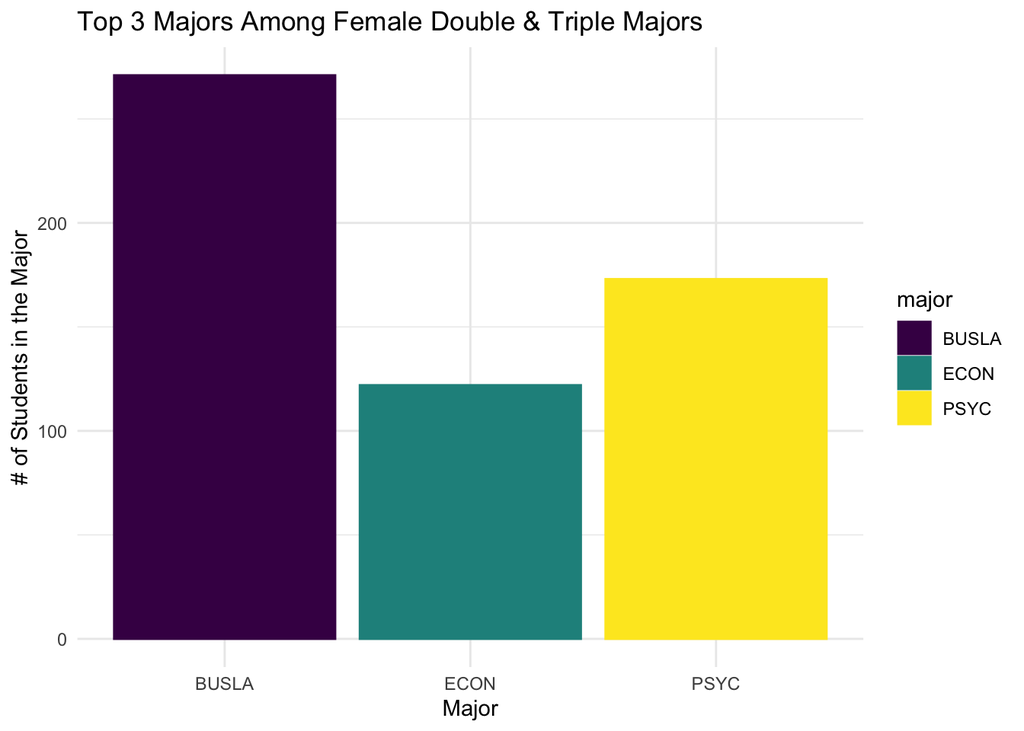

```r
ggplot(data = majors_option2f, aes(x = major, y = n_total)) +
  geom_col(aes(colour = major, fill = major)) +
  labs(title = "Top 3 Majors Among Female Double & Triple Majors",
       x = "Major",
       y = "# of Students in the Major") +
  scale_colour_viridis_d() +
  scale_fill_viridis_d() +
  theme_minimal()
```